# Titanic

Rohit Aggarwal

February 27, 2016

This is the code submitted by Rohit Aggarwal towards the Kaggle competition on predicting survival status of different passengers on Titanic ship.

## Include Relevant Packages

```r
library(ggplot2)
library(lattice)
library(randomForest)
library(rattle)
library(rpart)
library(rpart.plot)
library(RColorBrewer)
```

## Load training and testing data of titanic crew and passengers surviving/not surviving the crash

```r
train <- read.csv("http://s3.amazonaws.com/assets.datacamp.com/course/Kaggle/train.csv")
test <- read.csv("http://s3.amazonaws.com/assets.datacamp.com/course/Kaggle/test.csv")
str(train)
```

```
## 'data.frame':    891 obs. of  12 variables:
##  $ PassengerId: int  1 2 3 4 5 6 7 8 9 10 ...
##  $ Survived   : int  0 1 1 1 0 0 0 0 1 1 ...
##  $ Pclass     : int  3 1 3 1 3 3 1 3 3 2 ...
##  $ Name       : Factor w/ 891 levels "Abbing, Mr. Anthony",..: 109 191 358 277 16 559 520 629 417 581 ...
##  $ Sex        : Factor w/ 2 levels "female","male": 2 1 1 1 2 2 2 2 1 1 ...
##  $ Age        : num  22 38 26 35 35 NA 54 2 27 14 ...
##  $ SibSp      : int  1 1 0 1 0 0 0 3 0 1 ...
##  $ Parch      : int  0 0 0 0 0 0 0 1 2 0 ...
##  $ Ticket     : Factor w/ 681 levels "110152","110413",..: 524 597 670 50 473 276 86 396 345 133 ...
##  $ Fare       : num  7.25 71.28 7.92 53.1 8.05 ...
##  $ Cabin      : Factor w/ 148 levels "","A10","A14",..: 1 83 1 57 1 1 131 1 1 1 ...
##  $ Embarked   : Factor w/ 4 levels "","C","Q","S": 4 2 4 4 4 3 4 4 4 2 ...
```

```r
str(test)
```

```
## 'data.frame':    418 obs. of  11 variables:
##  $ PassengerId: int  892 893 894 895 896 897 898 899 900 901 ...
##  $ Pclass     : int  3 3 2 3 3 3 3 2 3 3 ...
##  $ Name       : Factor w/ 418 levels "Abbott, Master. Eugene Joseph",..: 210 409 273 414 182 370 85 58 5 104 ...
##  $ Sex        : Factor w/ 2 levels "female","male": 2 1 2 2 1 2 1 2 1 2 ...
##  $ Age        : num  34.5 47 62 27 22 14 30 26 18 21 ...
##  $ SibSp      : int  0 1 0 0 1 0 0 1 0 2 ...
##  $ Parch      : int  0 0 0 0 1 0 0 1 0 0 ...
##  $ Ticket     : Factor w/ 363 levels "110469","110489",..: 153 222 74 148 139 262 159 85 101 270 ...
##  $ Fare       : num  7.83 7 9.69 8.66 12.29 ...
##  $ Cabin      : Factor w/ 77 levels "","A11","A18",..: 1 1 1 1 1 1 1 1 1 1 ...
##  $ Embarked   : Factor w/ 3 levels "C","Q","S": 2 3 2 3 3 3 2 3 1 3 ...
```

## Test whether sex played a role in survival rate or not - it is more likely that females were saved before men

```r
table(train$Survived)
```

```
##
##   0   1
## 549 342
```

```r
prop.table(table(train$Survived)) # As proportions
```

```
##
##         0         1
## 0.6161616 0.3838384
```

```r
table(train$Sex, train$Survived)  # Males & females that survived vs males & females that passed away
```

```
##
##            0   1
##   female  81 233
##   male   468 109
```

```r
prop.table(table(train$Sex, train$Survived), margin=1)
```

```
##
##                  0         1
##   female 0.2579618 0.7420382
##   male   0.8110919 0.1889081
```

So, it is clear that females had a higher change of survival. ## Test whether age played a role in survival rate or not - it is more likely that children were saved first

```r
train$Child <- (train$Age < 18)
train$Child[train$Child == T] = 1
train$Child[train$Child == F] = 0
prop.table(table(train$Child, train$Survived), margin=1)
```

```
##
##             0         1
##   0 0.6189684 0.3810316
##   1 0.4601770 0.5398230
```

We see that females had over a 50% chance of surviving and males had less than a 50% chance of surviving. Lets make a test predictor that saves all females.

```
test_one <- test
test_one$Survived <- 0
test_one$Survived[test_one$Sex == "female"] = 1 # Set Survived to 1 if Sex equals "female"
```

Check for accuracy of this test on the training set

```r
train_copy <- train
train_copy$hypo_test1<- 0
train_copy$hypo_test1[train$Sex == "female"] = 1 # Set Survived to 1 if Sex equals "female"

table(train_copy$Survived, train_copy$hypo_test1)
```

```
##
##       0   1
##   0 468  81
##   1 109 233
```

# Model using decision trees

We notice that this test has a high error. Note that we could have also used a cross validation set via partitioning the training set via createDataPartition command in Caret package but we do not do that here to save time. The command to create partitions is createDataPartition(train$Age, p = 0.7, list=FALSE) model using decision trees

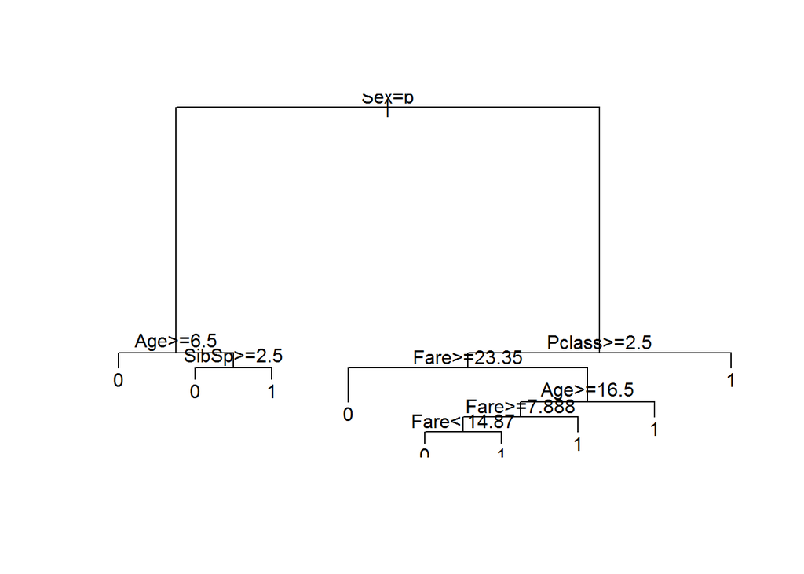

```r
model <- rpart(formula = Survived ~ Pclass + Sex + Age + SibSp + Parch + Fare, data = train, method = "class")
#model <- train(Survived ~Pclass + Sex + Age + SibSp + Parch + Fare, data = train, method = "rpart")
plot(model)
text(model)
```

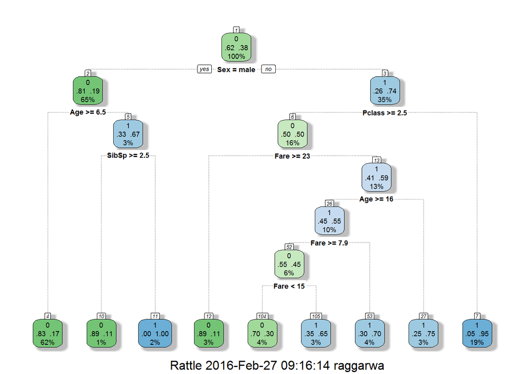

```r
fancyRpartPlot(model)
```

# Get predictions on test data

```
predictions <- predict(model, test, method="class")
solution_v2 <- numeric(nrow(predictions))
solution_v2[predictions[,1] < 0.5] <- 1
my_solution <- data.frame(PassengerId = test$PassengerId, Survived = solution_v2)
write.csv(my_solution, "my_solution.csv", row.names = FALSE)
```

We now Use classification trees to split only when the number of entries in a bucket is 50 and the number of splits can be any number “cp”. We further use the idea that larger families need more time to get together on a sinking ship, and hence have less chance of surviving. Family size is determined by the variables SibSp and Parch, which indicate the number of family members a certain passenger is traveling with. So when doing feature engineering, we add a new variable family_size, which is the sum of SibSp and Parch plus one (the observation itself), to the test and train set.

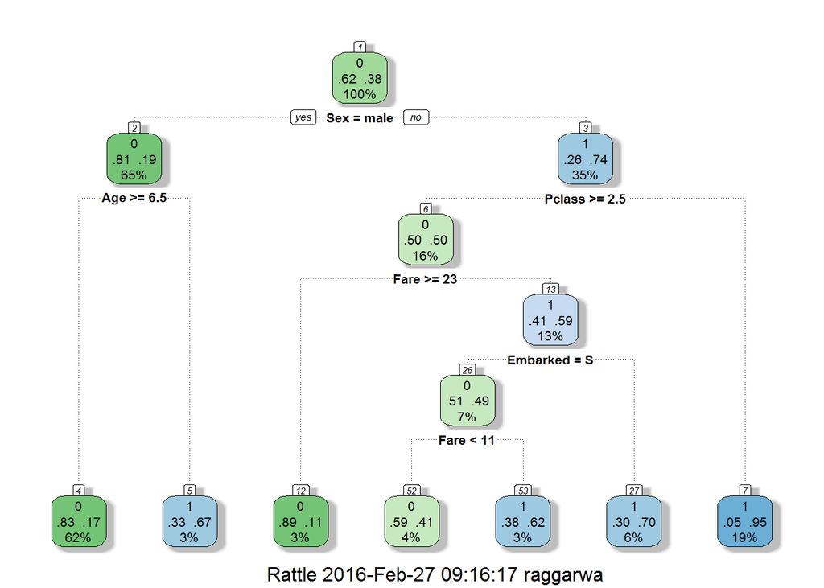

```r
train_two <- train
train_two$family_size <- train_two$SibSp + train_two$Parch + 1
my_tree_two<- rpart(Survived ~ Pclass + Sex + Age + SibSp + Parch + Fare + Embarked + family_size, data = train_two, method="class", control = rpart.control(minsplit = 50, cp = 0))
fancyRpartPlot(my_tree_two)
```

# Using random forests.

Why? Because random forests grows multiple (very deep) classification trees using the training set. At the time of prediction, each tree is used to come up with a prediction and every outcome is counted as a vote. This gives redundancy to our predictor and increases accuracy. This is also called bagging (= Bootstrap AGGregatING). However, this requires no gaps in data. S, we need to clean the data a little bit.

```r
test$Survived <- 0
test$Child <- (test$Age<18)
str(train)
```

```
## 'data.frame':    891 obs. of  13 variables:
##  $ PassengerId: int  1 2 3 4 5 6 7 8 9 10 ...
##  $ Survived   : int  0 1 1 1 0 0 0 0 1 1 ...
##  $ Pclass     : int  3 1 3 1 3 3 1 3 3 2 ...
##  $ Name       : Factor w/ 891 levels "Abbing, Mr. Anthony",..: 109 191 358 277 16 559 520 629 417 581 ...
##  $ Sex        : Factor w/ 2 levels "female","male": 2 1 1 1 2 2 2 2 1 1 ...
##  $ Age        : num  22 38 26 35 35 NA 54 2 27 14 ...
##  $ SibSp      : int  1 1 0 1 0 0 0 3 0 1 ...
##  $ Parch      : int  0 0 0 0 0 0 0 1 2 0 ...
##  $ Ticket     : Factor w/ 681 levels "110152","110413",..: 524 597 670 50 473 276 86 396 345 133 ...
##  $ Fare       : num  7.25 71.28 7.92 53.1 8.05 ...
##  $ Cabin      : Factor w/ 148 levels "","A10","A14",..: 1 83 1 57 1 1 131 1 1 1 ...
##  $ Embarked   : Factor w/ 4 levels "","C","Q","S": 4 2 4 4 4 3 4 4 4 2 ...
##  $ Child      : num  0 0 0 0 0 NA 0 1 0 1 ...
```

```r
str(test)
```

```
## 'data.frame':    418 obs. of  13 variables:
##  $ PassengerId: int  892 893 894 895 896 897 898 899 900 901 ...
##  $ Pclass     : int  3 3 2 3 3 3 3 2 3 3 ...
##  $ Name       : Factor w/ 418 levels "Abbott, Master. Eugene Joseph",..: 210 409 273 414 182 370 85 58 5 104 ...
##  $ Sex        : Factor w/ 2 levels "female","male": 2 1 2 2 1 2 1 2 1 2 ...
##  $ Age        : num  34.5 47 62 27 22 14 30 26 18 21 ...
##  $ SibSp      : int  0 1 0 0 1 0 0 1 0 2 ...
##  $ Parch      : int  0 0 0 0 1 0 0 1 0 0 ...
##  $ Ticket     : Factor w/ 363 levels "110469","110489",..: 153 222 74 148 139 262 159 85 101 270 ...
##  $ Fare       : num  7.83 7 9.69 8.66 12.29 ...
##  $ Cabin      : Factor w/ 77 levels "","A11","A18",..: 1 1 1 1 1 1 1 1 1 1 ...
##  $ Embarked   : Factor w/ 3 levels "C","Q","S": 2 3 2 3 3 3 2 3 1 3 ...
##  $ Survived   : num  0 0 0 0 0 0 0 0 0 0 ...
##  $ Child      : logi  FALSE FALSE FALSE FALSE FALSE TRUE ...
```

```r
total <- rbind(train,test)
str(total)
```

```
## 'data.frame':    1309 obs. of  13 variables:
##  $ PassengerId: int  1 2 3 4 5 6 7 8 9 10 ...
##  $ Survived   : num  0 1 1 1 0 0 0 0 1 1 ...
##  $ Pclass     : int  3 1 3 1 3 3 1 3 3 2 ...
##  $ Name       : Factor w/ 1307 levels "Abbing, Mr. Anthony",..: 109 191 358 277 16 559 520 629 417 581 ...
##  $ Sex        : Factor w/ 2 levels "female","male": 2 1 1 1 2 2 2 2 1 1 ...
##  $ Age        : num  22 38 26 35 35 NA 54 2 27 14 ...
##  $ SibSp      : int  1 1 0 1 0 0 0 3 0 1 ...
##  $ Parch      : int  0 0 0 0 0 0 0 1 2 0 ...
##  $ Ticket     : Factor w/ 929 levels "110152","110413",..: 524 597 670 50 473 276 86 396 345 133 ...
##  $ Fare       : num  7.25 71.28 7.92 53.1 8.05 ...
##  $ Cabin      : Factor w/ 187 levels "","A10","A14",..: 1 83 1 57 1 1 131 1 1 1 ...
##  $ Embarked   : Factor w/ 4 levels "","C","Q","S": 4 2 4 4 4 3 4 4 4 2 ...
##  $ Child      : num  0 0 0 0 0 NA 0 1 0 1 ...
```

Passenger on row 62 and 830 do not have a value for embarkment. Since many passengers embarked at Southampton, we give them the value S.

```
total$Embarked[c(62, 830)] <- "S"
```

Factorize embarkment codes.

```
total$Embarked <- factor(total$Embarked)
```

Passenger on row 1044 has an NA Fare value. Let’s replace it with the median fare value.

```
total$Fare[1044] <- median(total$Fare, na.rm = TRUE)
```

# Age is not given for many entries so we predict age first.

```
model <- rpart(Age ~ Pclass + Sex + SibSp + Parch + Fare + Embarked, data = total[!is.na(total$Age),], method="anova") # We use Anova because we are predicting a continuous random variable
total$Age[is.na(total$Age)] <- predict(model, total[is.na(total$Age),])
```

# Split the data back into a train set and a test set

```
train <- total[1:891,]
test <- total[892:1309,]
set.seed(111)
```

# Do final modeling and prediction

```
my_forest <- randomForest(as.factor(Survived) ~ Pclass + Sex + Age + SibSp + Parch + Fare, total, importance = TRUE, ntree = 1000)
my_prediction <- predict(my_forest, test)
my_solution_v3 <- data.frame(PassengerId = test$PassengerId, Survived = my_prediction)
write.csv(my_solution_v3, file = "my_solution_v3.csv", row.names = FALSE)
```